# Analyzing an Upcoming Opponent Project

```r
punt_ret_yds <- c(0,0)
punts <- cbind(punts, punt_ret_yds)
#combining summaries
offense_summary <- pass_plays_sum %>% left_join(run_plays_sum,by = join_by(pff_OFFTEAM)) %>% left_join(num_plays,by = join_by(pff_OFFTEAM)) %>%
  left_join(penalties, by=c('pff_OFFTEAM'='penalty_team')) %>% left_join(turnovers_df, by = join_by(pff_OFFTEAM)) %>%
  left_join(red_zone_df, by = join_by(pff_OFFTEAM)) %>% left_join(thrd_frth_df, by = join_by(pff_OFFTEAM)) %>%
  left_join(first_downs, by = join_by(pff_OFFTEAM)) %>% left_join(pat_attempts_df, by = join_by(pff_OFFTEAM)) %>%
  left_join(two_point_df, by = join_by(pff_OFFTEAM)) %>% left_join(field_goals, by = join_by(pff_OFFTEAM)) %>%
  left_join(touchdown_total, by=c('pff_OFFTEAM'='team_touchdown')) %>% left_join(top_final, by = join_by(pff_OFFTEAM)) %>%
  left_join(kickoffs_final, by = join_by(pff_OFFTEAM)) %>% left_join(punts, by = join_by(pff_OFFTEAM)) %>%
  mutate(offensive_yards = rush_yards + passing_yards, yards_per_play = round(offensive_yards/plays,1))
#getting final score
final_score <- plays %>% slice(n()) %>% select(pff_DEFTEAM, pff_DEFSCORE, pff_OFFTEAM, pff_OFFSCORE)
cowboys_score <- final_score %>% select(pff_OFFTEAM,pff_OFFSCORE) %>% rename(score = pff_OFFSCORE)
eagles_score <- final_score %>% select(pff_DEFTEAM,pff_DEFSCORE) %>% rename(pff_OFFTEAM=pff_DEFTEAM,score = pff_DEFSCORE)
final_score_df <- rbind(cowboys_score, eagles_score)
#looking at offensive summary
offense_summary <- offense_summary %>% left_join(final_score_df, by = join_by(pff_OFFTEAM))
offense_summary %>% gt()
```

| pff_OFFTEAM | completions | pass_attempts | passing_yards | completion_pct | yards_per_attempt | yards_per_completion | passing_touchdowns | intercpetions | sacks_taken | sack_yds_lost | passer_rating | rush_attempts | rush_yards | yards_per_carry | rushing_touchdowns | plays | penalties | penalty_yards_tot | interceptions | fumbles | fumbles_lost | Turnovers | red_zone_trips | redZone_success | red_zone_pct | third_downs | fourth_downs | third_down_convs | fourth_down_convs | … |
| --- | --- | --- | --- | --- | --- | --- | --- | --- | --- | --- | --- | --- | --- | --- | --- | --- | --- | --- | --- | --- | --- | --- | --- | --- | --- | --- | --- | --- | --- | --- |
| DAL | 27 | 35 | 304 | 77.1 | 8.7 | 11.3 | 3 | 1 | 6 | 43 | 119.2 | 31 | 115 | 3.7 | 1 | 72 | 4 | 36 | 1 | 1 | 0 | 1 | 5 | 3 | 60 | 15 | 1 | 8 | 1 | … |
| PHI | 24 | 40 | 355 | 60.0 | 8.9 | 14.8 | 2 | 2 | 0 | 0 | 84.9 | 29 | 89 | 3.1 | 1 | 69 | 2 | 10 | 2 | 3 | 2 | 4 | 5 | 3 | 60 | 14 | 3 | 8 | 2 | … |

Defensive Summaries

```r
#getting interception return yards
int_yards_df <- plays %>% filter(grepl("intercepted",tolower(PlayDescription))==TRUE) %>%
  mutate(int_yards = sub(".*intercepted ", "", tolower(PlayDescription))) %>%
  mutate(int_yards = sub(".*for ", "", tolower(PlayDescription)))

int_yards_final <- int_yards_df %>% mutate(int_yards = sub(" yards.*", "", tolower(int_yards))) %>%
  mutate(int_yards = ifelse(grepl("no gain",tolower(PlayDescription)) == TRUE,0,int_yards)) %>%
  mutate(int_yards = as.numeric(int_yards)) %>% mutate(pick_6 = ifelse(pff_DRIVEENDEVENT == "INTERCEPTION-TD",1,0)) %>% group_by(pff_DEFTEAM) %>% summarise(int_ret_yards = sum(int_yards), pick_sixes = sum(pick_6))

#fumbles
fumbles_df <- defense %>% mutate(pff_FORCEDFUMBLE = ifelse(pff_FORCEDFUMBLE == "Y",1,0), pff_FUMBLERECOVERED = ifelse(pff_FUMBLERECOVERED == "Y",1,0)) %>%
  group_by(pff_TEAM) %>% summarise(forced_fumbled = sum(pff_FORCEDFUMBLE, na.rm = T), recovered_fumbles = sum(pff_FUMBLERECOVERED, na.rm = T))

#sacks
sacks_df <- plays %>% mutate(sack_yards = ifelse(plays$pff_PASSRESULT == "SACK",abs(plays$pff_GAINLOSSNET),0)) %>%
  group_by(pff_DEFTEAM) %>% summarise(sack_yards = sum(sack_yards, na.rm = T), sacks = sum(pff_PASSRESULT == "SACK", na.rm = T))

#defense summary
deffense_summary <- defense %>% mutate(pff_PASSBREAKUP = ifelse(pff_PASSBREAKUP == "Y",1,0), pff_INTERCEPTION = ifelse(pff_INTERCEPTION == "Y",1,0),
                   pff_DROPPEDINTERCEPTION = ifelse(pff_DROPPEDINTERCEPTION == "Y",1,0)) %>%
  group_by(pff_TEAM) %>% summarise(pass_breakups = sum(pff_PASSBREAKUP, na.rm = T), pass_interceptions = sum(pff_INTERCEPTION, na.rm = T),
                                   dropped_ints = sum(as.numeric(pff_DROPPEDINTERCEPTION), na.rm = T)) %>%
  left_join(int_yards_final, by=c('pff_TEAM'='pff_DEFTEAM')) %>% left_join(fumbles_df, by=join_by(pff_TEAM)) %>%
  left_join(sacks_df, by=c('pff_TEAM'='pff_DEFTEAM'))
#looking at defense summary
deffense_summary %>% gt()
```

| pff_TEAM | pass_breakups | pass_interceptions | dropped_ints | int_ret_yards | pick_sixes | forced_fumbled | recovered_fumbles | sack_yards | sacks |
| --- | --- | --- | --- | --- | --- | --- | --- | --- | --- |
| DAL | 1 | 2 | 1 | 2 | 0 | 1 | 2 | 0 | 0 |
| PHI | 2 | 1 | 0 | 42 | 1 | 1 | 0 | 43 | 6 |

Final team summary stats

```r
team_summary_df <- deffense_summary %>% left_join(offense_summary, by=c('pff_TEAM'='pff_OFFTEAM'))
#looking at full team summary
team_summary_df %>% gt()
```

| pff_TEAM | pass_breakups | pass_interceptions | dropped_ints | int_ret_yards | pick_sixes | forced_fumbled | recovered_fumbles | sack_yards | sacks | completions | pass_attempts | passing_yards | completion_pct | yards_per_attempt | yards_per_completion | passing_touchdowns | intercpetions | sacks_taken | sack_yds_lost | passer_rating | rush_attempts | rush_yards | yards_per_carry | rushing_touchdowns | plays | penalties | penalty_yards_tot | interceptions | fumbles | … |
| --- | --- | --- | --- | --- | --- | --- | --- | --- | --- | --- | --- | --- | --- | --- | --- | --- | --- | --- | --- | --- | --- | --- | --- | --- | --- | --- | --- | --- | --- | --- |
| DAL | 1 | 2 | 1 | 2 | 0 | 1 | 2 | 0 | 0 | 27 | 35 | 304 | 77.1 | 8.7 | 11.3 | 3 | 1 | 6 | 43 | 119.2 | 31 | 115 | 3.7 | 1 | 72 | 4 | 36 | 1 | 1 | … |
| PHI | 2 | 1 | 0 | 42 | 1 | 1 | 0 | 43 | 6 | 24 | 40 | 355 | 60.0 | 8.9 | 14.8 | 2 | 2 | 0 | 0 | 84.9 | 29 | 89 | 3.1 | 1 | 69 | 2 | 10 | 2 | 3 | … |

By Player summary stats offense

```r
#getting player passing stats
qbs_df <- offense %>% filter(pff_POSITION == "QB", pff_NOPLAY == 0) %>% left_join(pass_plays, by = join_by(pff_PLAYID))
qbs_df$pass_touchdown <- ifelse((qbs_df$pff_ROLE == "Pass")&(qbs_df$pff_TOUCHDOWN.x == "Y"),1,0)

qb_summary <- qbs_df %>% group_by(PlayerName) %>% summarise(pass_yards = sum(pff_PASSINGYARDS, na.rm = T), attempts = sum(attempt, na.rm = T),
                                              completions = sum(pff_PASSRESULT == "COMPLETE", na.rm = T),
                                              intercpetions = sum(pff_PASSRESULT == "INTERCEPTION", na.rm = T),
                                              longest_pass = max(pff_PASSINGYARDS, na.rm = T), sacks_taken = sum(pff_PASSRESULT == "SACK", na.rm = T),
                                              touchdowns = sum(pass_touchdown, na.rm = T))

passing_players <- qb_summary %>%
  mutate(passer_rating = round((((((completions/attempts)-.3)*5) + (((pass_yards/attempts)-3)*.25) + ((touchdowns/attempts)*20) +(2.375-((intercpetions/attempts)*25)))/6)*100,1), yards_per_attempt = round(pass_yards/attempts,1), comp_pct = round(completions/attempts,3)*100)
#looking at passing players
passing_players %>% gt()
```

| PlayerName | pass_yards | attempts | completions | intercpetions | longest_pass | sacks_taken | touchdowns | passer_rating | yards_per_attempt | comp_pct |
| --- | --- | --- | --- | --- | --- | --- | --- | --- | --- | --- |
| MINSHEW, GARDNER | 355 | 40 | 24 | 2 | 48 | 0 | 2 | 84.9 | 8.9 | 60.0 |
| PRESCOTT, RAYNE | 347 | 35 | 27 | 1 | 52 | 6 | 3 | 124.3 | 9.9 | 77.1 |

```r
#getting player rushing stats
rushing_df <- offense %>% filter(is.na(pff_RUSHINGYARDS) == FALSE, pff_NOPLAY == 0)
rushing_summary <- rushing_df %>% group_by(PlayerName) %>% summarise(carries = n(),rush_yards = sum(pff_RUSHINGYARDS), yards_per_carry = round(rush_yards/carries,1),
                                                  touchdowns = sum((pff_TOUCHDOWN == "Y") == TRUE,na.rm = T), longest_run = max(pff_RUSHINGYARDS, na.rm = T),
                                                  fumbles_lost = sum((pff_FUMBLE == "Y") == TRUE,na.rm = T))
#looking at rushing stats
rushing_summary %>% gt()
```

| PlayerName | carries | rush_yards | yards_per_carry | touchdowns | longest_run | fumbles_lost |
| --- | --- | --- | --- | --- | --- | --- |
| ELLIOTT, EZEKIEL | 16 | 55 | 3.4 | 1 | 22 | 0 |
| GAINWELL, KENNETH | 4 | 17 | 4.2 | 0 | 11 | 0 |
| MINSHEW, GARDNER | 4 | 5 | 1.2 | 1 | 3 | 1 |
| POLLARD, TONY | 9 | 19 | 2.1 | 0 | 8 | 0 |
| PRESCOTT, RAYNE | 6 | 41 | 6.8 | 0 | 16 | 0 |
| SANDERS, MILES | 21 | 67 | 3.2 | 0 | 13 | 1 |

```r
#getting player receiving stats
receiving_df <- offense %>% filter(is.na(pff_RECEIVINGYARDS) == FALSE, pff_NOPLAY == 0)
receiving_summary <- receiving_df %>% group_by(pff_TEAM,PlayerName) %>% summarise(receiving_yards = sum(pff_RECEIVINGYARDS), receptions = n(),
                                                             longest_rec = max(pff_RECEIVINGYARDS, na.rm = T),
                                                             touchdowns = sum((pff_TOUCHDOWN == "Y") == TRUE,na.rm = T))
#getting target and other receiving stats
players_w_rec_yards <- offense %>% filter(PlayerName %in% receiving_summary$PlayerName, pff_NOPLAY == 0)

targets_df <- players_w_rec_yards %>% group_by(pff_TEAM, PlayerName) %>% summarise(targets = sum((pff_TARGETEDRECEIVER == "Y") == TRUE,na.rm = T))

#merging two receiving data frames to get final stats
receiving_summary <- receiving_summary %>% left_join(targets_df, by = join_by(PlayerName, pff_TEAM)) %>%
  mutate(yards_per_target = round(receiving_yards/targets,1), yards_per_reception = round(receiving_yards/receptions,1))
#looking at receiving summary
receiving_summary %>% gt()
```

| PlayerName | receiving_yards | receptions | longest_rec | touchdowns | targets | yards_per_target | yards_per_reception |
| --- | --- | --- | --- | --- | --- | --- | --- |
| DAL |  |  |  |  |  |  |  |
| BROWN, NOAH | 5 | 1 | 5 | 0 | 2 | 2.5 | 5.0 |
| ELLIOTT, EZEKIEL | 6 | 1 | 6 | 0 | 1 | 6.0 | 6.0 |
| FERGUSON, JONATHAN | 24 | 1 | 24 | 0 | 1 | 24.0 | 24.0 |
| GALLUP, MICHAEL | 36 | 4 | 12 | 1 | 7 | 5.1 | 9.0 |
| HILTON, EUGENE | 52 | 1 | 52 | 0 | 1 | 52.0 | 52.0 |
| LAMB, CEEDEE | 120 | 10 | 36 | 2 | 11 | 10.9 | 12.0 |
| POLLARD, TONY | 61 | 6 | 13 | 0 | 8 | 7.6 | 10.2 |
| SCHULTZ, DALTON | 43 | 3 | 21 | 0 | 4 | 10.8 | 14.3 |
| PHI |  |  |  |  |  |  |  |
| BROWN, ARTHUR | 103 | 6 | 48 | 0 | 7 | 14.7 | 17.2 |
| GAINWELL, KENNETH | 41 | 4 | 20 | 0 | 4 | 10.2 | 10.2 |
| GOEDERT, DALLAS | 67 | 3 | 25 | 0 | 3 | 22.3 | 22.3 |
| PASCAL, ZACHARY | 6 | 1 | 6 | 0 | 1 | 6.0 | 6.0 |
| SANDERS, MILES | 6 | 1 | 6 | 0 | 1 | 6.0 | 6.0 |
| SMITH, DEVONTA | 113 | 8 | 23 | 2 | 12 | 9.4 | 14.1 |
| WATKINS, QUEZ | 19 | 1 | 19 | 0 | 5 | 3.8 | 19.0 |

By player stats defense

```r
#making columns able to add - changing character to numeric
defense <- defense %>% mutate(pff_TACKLE = ifelse(pff_TACKLE == "Y",1,0), asst_tackle = ifelse(pff_ASSIST == "Y",1,0), sack = ifelse(pff_SACK == "Y",1,0),
                              pff_FORCEDFUMBLE = ifelse(pff_FORCEDFUMBLE == "Y",1,0), pff_INTERCEPTION = ifelse(pff_INTERCEPTION == "Y",1,0),
                              pff_TOUCHDOWN = ifelse(pff_TOUCHDOWN == "Y",1,0), pff_BATTEDPASS = ifelse(pff_BATTEDPASS == "Y",1,0),
                              pff_PASSBREAKUP = ifelse(pff_PASSBREAKUP == "Y",1,0))
#getting plays where sacks occured
sack_plays <- defense %>% group_by(pff_PLAYID) %>% summarise(players_w_sack = sum(sack, na.rm = T))

defense <- defense %>% left_join(sack_plays, by = join_by(pff_PLAYID))

#replacing NA's with 0's in sack column
defense$sack <- ifelse(is.na(defense$sack),0,defense$sack)

#getting the sack total of players
defense$sack_total <- ifelse((defense$players_w_sack < 2) & (defense$sack == 1),1,
                             ifelse((defense$players_w_sack > 1)&(defense$sack == 1),0.5,0))
#making defensive player summary stats
player_summary_def <- defense %>% filter(pff_NOPLAY == 0,special_teams == 0) %>% group_by(pff_TEAM, PlayerName) %>%
  summarise(tackles = sum(pff_TACKLE, na.rm = T), asst_tackles = sum(asst_tackle, na.rm = T),
            tot_tackles = tackles+asst_tackles, sacks = sum(sack_total, na.rm = T), forced_fumbles = sum(pff_FORCEDFUMBLE, na.rm = T),
            interceptions = sum(pff_INTERCEPTION, na.rm = T), touchdowns = sum(pff_TOUCHDOWN, na.rm = T),
            batted_passes = sum(pff_BATTEDPASS, na.rm = T), pass_breakups = sum(pff_PASSBREAKUP, na.rm = T))
#looking at player summary for defense
player_summary_def %>% gt()
```

| PlayerName | tackles | asst_tackles | tot_tackles | sacks | forced_fumbles | interceptions | touchdowns | batted_passes | pass_breakups |
| --- | --- | --- | --- | --- | --- | --- | --- | --- | --- |
| DAL |  |  |  |  |  |  |  |  |  |
| ALEXANDER, MACKENSIE | 1 | 0 | 1 | 0.0 | 0 | 0 | 0 | 0 | 0 |
| ARMSTRONG, DORANCE | 1 | 0 | 1 | 0.0 | 0 | 0 | 0 | 0 | 0 |
| BARR, ANTHONY | 4 | 3 | 7 | 0.0 | 0 | 0 | 0 | 0 | 0 |
| BLAND, DARON | 5 | 0 | 5 | 0.0 | 0 | 1 | 0 | 0 | 0 |
| BOHANNA, QUINTON | 1 | 1 | 2 | 0.0 | 0 | 0 | 0 | 0 | 0 |
| CLARK, DAMONE | 2 | 3 | 5 | 0.0 | 0 | 0 | 0 | 0 | 0 |
| DIGGS, TREVON | 2 | 0 | 2 | 0.0 | 0 | 0 | 0 | 0 | 0 |
| FOWLER, DANTE | 0 | 0 | 0 | 0.0 | 0 | 0 | 0 | 0 | 0 |
| GALLIMORE, NEVILLE | 1 | 1 | 2 | 0.0 | 0 | 0 | 0 | 0 | 0 |
| GIFFORD, LUKE | 1 | 0 | 1 | 0.0 | 0 | 0 | 0 | 0 | 0 |
| GOLSTON, CHAUNCEY | 0 | 0 | 0 | 0.0 | 0 | 0 | 0 | 0 | 0 |
| HOOKER, MALIK | 5 | 0 | 5 | 0.0 | 0 | 0 | 0 | 0 | 0 |
| KEARSE, JAYRON | 3 | 0 | 3 | 0.0 | 0 | 1 | 0 | 0 | 0 |
| LAWRENCE, DEMARCUS | 3 | 1 | 4 | 0.0 | 0 | 0 | 0 | 0 | 0 |
| MUKUAMU, ISRAEL | 1 | 0 | 1 | 0.0 | 0 | 0 | 0 | 0 | 0 |
| ODIGHIZUWA, OSAWARU | 1 | 0 | 1 | 0.0 | 0 | 0 | 0 | 0 | 0 |
| PARSONS, MICAH | 3 | 1 | 4 | 0.0 | 0 | 0 | 0 | 0 | 0 |
| WATKINS, CARLOS | 1 | 1 | 2 | 0.0 | 1 | 0 | 0 | 0 | 0 |
| WILSON, DONOVAN | 6 | 1 | 7 | 0.0 | 0 | 0 | 0 | 0 | 0 |
| WRIGHT, NAHSHON | 6 | 2 | 8 | 0.0 | 0 | 0 | 0 | 0 | 1 |
| PHI |  |  |  |  |  |  |  |  |  |
| BLANKENSHIP, REED | 6 | 2 | 8 | 0.0 | 0 | 0 | 0 | 0 | 0 |
| BRADBERRY, JAMES | 2 | 0 | 2 | 0.0 | 0 | 0 | 0 | 0 | 1 |
| COX, FLETCHER | 2 | 0 | 2 | 0.0 | 0 | 0 | 0 | 0 | 0 |
| DAVIS, JORDAN | 1 | 1 | 2 | 0.0 | 0 | 0 | 0 | 0 | 0 |
| DEAN, NAKOBE | 0 | 0 | 0 | 0.0 | 0 | 0 | 0 | 0 | 0 |
| EDWARDS, TERRENCE | 11 | 3 | 14 | 0.0 | 0 | 0 | 0 | 0 | 0 |
| EPPS, MARCUS | 5 | 1 | 6 | 0.0 | 0 | 0 | 0 | 0 | 0 |
| GRAHAM, BRANDON | 1 | 0 | 1 | 0.5 | 0 | 0 | 0 | 0 | 0 |
| HARGRAVE, JAVON | 0 | 1 | 1 | 0.0 | 0 | 0 | 0 | 0 | 0 |
| JOHNSON, PATRICK | 1 | 0 | 1 | 0.0 | 0 | 0 | 0 | 0 | 0 |
| JOSEPH, LINVAL | 5 | 1 | 6 | 0.0 | 0 | 0 | 0 | 0 | 0 |
| MADDOX, AVONTE | 2 | 0 | 2 | 1.0 | 0 | 0 | 0 | 0 | 0 |
| REDDICK, HAASON | 2 | 0 | 2 | 2.0 | 1 | 0 | 0 | 0 | 0 |
| SCOTT, JOSIAH | 2 | 1 | 3 | 0.0 | 0 | 0 | 0 | 0 | 1 |
| SLAY, DARIUS | 2 | 1 | 3 | 0.0 | 0 | 0 | 0 | 0 | 0 |
| SUH, NDAMUKONG | 1 | 0 | 1 | 0.5 | 0 | 0 | 0 | 0 | 0 |
| SWEAT, JOSH | 0 | 1 | 1 | 1.5 | 0 | 1 | 1 | 0 | 0 |
| WALLACE, K'VON | 0 | 0 | 0 | 0.0 | 0 | 0 | 0 | 0 | 0 |
| WHITE, KYZIR | 4 | 1 | 5 | 0.5 | 0 | 0 | 0 | 0 | 0 |
| WILLIAMS, MILTON | 3 | 0 | 3 | 0.0 | 0 | 0 | 0 | 0 | 0 |

Lastly, getting offensive line summary stats

```r
#making data frame for offensive linemen
oline <- offense %>% filter(PosGroup == "OL", pff_NOPLAY == 0, special_teams == 0)

oline <- oline %>% mutate(pff_HITALLOWED = ifelse(pff_HITALLOWED == "Y",1,0), pff_HURRYALLOWED = ifelse(pff_HURRYALLOWED == "Y",1,0),
                 pff_PRESSUREALLOWED = ifelse(pff_PRESSUREALLOWED == "Y",1,0), pff_SACKALLOWED = ifelse(pff_SACKALLOWED == "Y",1,0),
                 pff_SCREENBLOCK = ifelse(pff_SCREENBLOCK == "Y",1,0))

oline_summary <- oline %>% group_by(pff_TEAM, PlayerName) %>% summarise(hits_allowed = sum(pff_HITALLOWED, na.rm = T), hurries_allowed = sum(pff_HURRYALLOWED, na.rm = T), pressures_allowed = sum(pff_PRESSUREALLOWED, na.rm = T), sacks_allowed = sum(pff_SACKALLOWED, na.rm = T), screen_blocks = sum(pff_SCREENBLOCK, na.rm = T))
#looking at offensive line stats
oline_summary %>% gt()
```

| PlayerName | hits_allowed | hurries_allowed | pressures_allowed | sacks_allowed | screen_blocks |
| --- | --- | --- | --- | --- | --- |
| DAL |  |  |  |  |  |
| BIADASZ, TYLER | 0 | 2 | 2 | 0 | 1 |
| MARTIN, ZACHARY | 0 | 1 | 1 | 0 | 0 |
| MCGOVERN, CONNOR | 0 | 2 | 2 | 0 | 0 |
| PETERS, JASON | 0 | 0 | 0 | 0 | 0 |
| SMITH, TYLER | 0 | 0 | 0 | 0 | 0 |
| SMITH, TYRON | 0 | 3 | 4 | 1 | 0 |
| PHI |  |  |  |  |  |
| DICKERSON, LANDON | 0 | 5 | 5 | 0 | 0 |
| DRISCOLL, JOHN | 0 | 1 | 1 | 0 | 0 |
| JOHNSON, LANE | 0 | 0 | 0 | 0 | 0 |
| KELCE, JASON | 0 | 0 | 0 | 0 | 0 |
| MAILATA, JORDAN | 0 | 6 | 6 | 0 | 0 |
| SEUMALO, ISAAC | 0 | 2 | 2 | 0 | 0 |

2). What worked for each team and what didn’t? Was there something a team should have done differently?

Looking at how well these temas did on Third Downs

```r
third_downs <- plays %>% filter(Down == 3, pff_NOPLAY == 0)
third_downs$pff_FIRSTDOWNGAINED <- ifelse(is.na(third_downs$pff_FIRSTDOWNGAINED) == TRUE,0,third_downs$pff_FIRSTDOWNGAINED)
#creating an indicator that shows short, medium, and long situations
#short is defined as 0-3 yards to go, medium is defined as 4-7 yards to go, and long is defined as 8 yards or more
third_downs$to_go_situation <- ifelse(third_downs$YardsToGo < 4,"Short",
                                      ifelse(third_downs$YardsToGo > 3 & third_downs$YardsToGo < 8,"Medium",
                                             ifelse(third_downs$YardsToGo > 7, "Long",NA)))
third_down_summary <- third_downs %>% group_by(pff_OFFTEAM, pff_RUNPASS, to_go_situation) %>% summarise(attempts = n(), firsts = sum(pff_FIRSTDOWNGAINED, na.rm = T), .groups = "keep")

#getting percent
third_down_summary <- third_down_summary %>% mutate(pct = round(firsts/attempts,2)*100)
third_down_summary
```

```
## # A tibble: 7 × 6
## # Groups:   pff_OFFTEAM, pff_RUNPASS, to_go_situation [7]
##   pff_OFFTEAM pff_RUNPASS to_go_situation attempts firsts   pct
##   <chr>       <chr>       <chr>              <int>  <dbl> <dbl>
## 1 DAL         P           Long                   3      2    67
## 2 DAL         P           Medium                 9      5    56
## 3 DAL         P           Short                  2      1    50
## 4 DAL         R           Short                  1      0     0
## 5 PHI         P           Long                   5      2    40
## 6 PHI         P           Medium                 6      5    83
## 7 PHI         R           Short                  3      1    33
```

```r
#third downs are a huge and very important part of the game. You need to convert on third downs to keep possesion of the ball and have control of the game. Dallas was very good in 3 and long situations. They were 2 for 3, which is a huge momentum swing each time they convert. They only passed in these situations but only missing on one the whole game is very impressive. When looking at how each team performed on third and mediums both teams only passed the ball. Philly however, was a lot more successful with converting 5 out of their 6 attempts, while the Cowboys were 5 for 9. In the case of the Cowboys, running once or twice during these situations probably would have made them less predictable and maybe even converted on one or two of them. In terms of third and short situations Philly ran on all 3 and only converted 1, while the Cowboys passed on 2 and converted 1, and ran 1 but did not get the first. I feel that Philly could have done better in the third and short situations since they ran the ball every time. Mayve running an RPO or a play action could have thrown the Cowboys defense off guard and they could've converted on more of them.
```

Looking at how well these teams did on First downs

```r
#gettng first down plays
first_downs <- plays %>% filter(Down == 1, pff_NOPLAY == 0)

#defining results of play
#loss will be defined as no gain or loss of yards, 3 yards or less will be defined as little_gain, more than 3 yards will be defined as good gain
first_downs$gain_type <- ifelse(first_downs$pff_GAINLOSS < 1|is.na(first_downs$pff_GAINLOSS) == TRUE,"Loss",
                                ifelse(first_downs$pff_GAINLOSS > 0 & first_downs$pff_GAINLOSS < 4,"Small Gain",
                                       ifelse(first_downs$pff_GAINLOSS > 3, "Good Gain",NA)))

first_downs_sum <- first_downs %>% group_by(pff_OFFTEAM, pff_RUNPASS ,gain_type) %>% summarise(count = n(), .groups = "keep") %>% ungroup()

first_downs_sum <- first_downs_sum %>% group_by(pff_OFFTEAM, pff_RUNPASS) %>% mutate(total_RP = sum(count), pct = round(count/total_RP,2)*100)

first_downs_sum
```

```
## # A tibble: 11 × 6
## # Groups:   pff_OFFTEAM, pff_RUNPASS [4]
##    pff_OFFTEAM pff_RUNPASS gain_type  count total_RP   pct
##    <chr>       <chr>       <chr>      <int>    <int> <dbl>
##  1 DAL         P           Good Gain      8       16    50
##  2 DAL         P           Loss           8       16    50
##  3 DAL         R           Good Gain      5       17    29
##  4 DAL         R           Loss           5       17    29
##  5 DAL         R           Small Gain     7       17    41
##  6 PHI         P           Good Gain      9       16    56
##  7 PHI         P           Loss           6       16    38
##  8 PHI         P           Small Gain     1       16     6
##  9 PHI         R           Good Gain      8       15    53
## 10 PHI         R           Loss           3       15    20
## 11 PHI         R           Small Gain     4       15    27
```

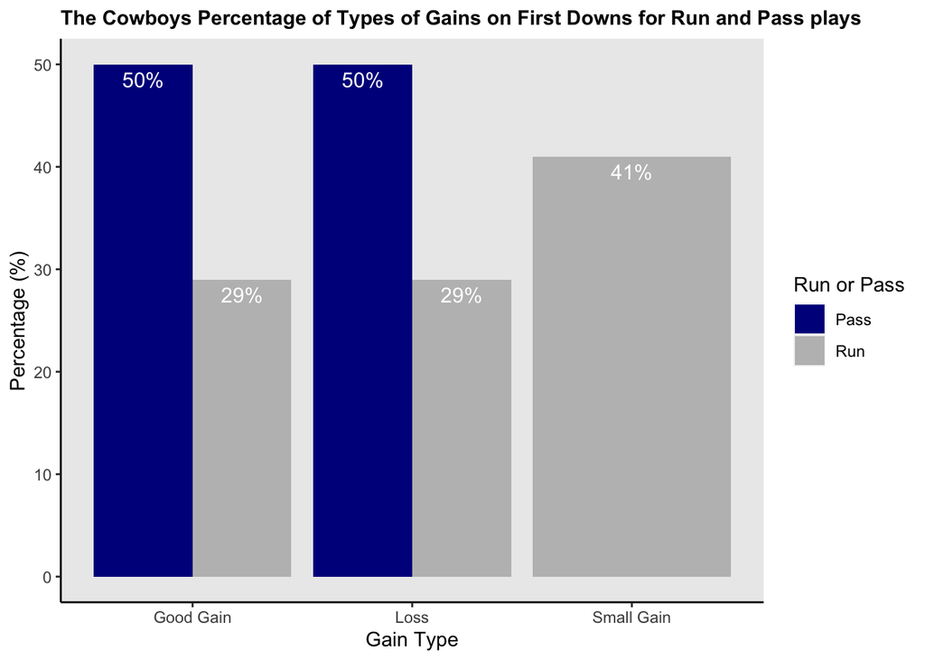

```r
#When passing on first down the Cowboys got a good gain 50% of the time and a loss 50% of the time. To me this is solid since you're not necessarily trying to get a first down every time on first down. But knowing that they got at least 4 yards 50% of the time when passing the ball on first is solid. When running the ball on first down the Cowboys had a good gain 29% of the time, a loss 29% of the time, and a small gain 41% of the time. To me this seems pretty average since a defense on first down usually is aiming to defend the run, and given that they Cowboys gained yardage on 70% on runs on first downs, I would think that's pretty impressive. Also they were pretty much 50/50 on whether than ran or passed the ball on first down, which is really good to keep the defense guessing.

#When passing on first down the eagles had a good gain 56% percent of the time while having a loss 38% of the time and a small gain 6% of the time. This is a bit better than it was for the Cowboys, and it does seem that the Eagles had a lot of success throwing it on first down. They gained more yards than they lost when passing so sticking to the pass game on firsts seems like a good option. When running on first downs the Eagles had a good gain 53% of the time, while having a loss 20% of the time, and a small gain 27% of the time. This is also very good, given that every time they ran the ball on first down they got at least a positive gain 80% of the time. However, given that they had at least 4 yards on a run play 53% of all their first downs leads me to believe that the Cowboys were playing a "bend but don't break" defense. This is probably because Jalen Hurts was out, who is a big part of the Eagles run game normally, and i'm guessing they didn't respect their running backs alone, so they decided to play the pass more on first downs rather than the run. I'm going to observe this more closely below.

#making R run and P pass in data frame
first_downs_sum$pff_RUNPASS <- ifelse(first_downs_sum$pff_RUNPASS == "P","Pass","Run")
#getting data frame for Eagles
eagles_first <- first_downs_sum %>% filter(pff_OFFTEAM == "PHI")
#getting data frame for Cowboys
cowboys_first <- first_downs_sum %>% filter(pff_OFFTEAM == "DAL")

#creating plot for cowboys
ggplot(cowboys_first, aes(x = gain_type, y = pct, fill = pff_RUNPASS)) + geom_bar(stat = "identity", position = "dodge") +
  ylab("Percentage (%)") + xlab("Gain Type") + ggtitle("The Cowboys Percentage of Types of Gains on First Downs for Run and Pass plays ")+ guides(fill=guide_legend(title="Run or Pass"))+geom_text(aes(label=paste(round(pct),"%",sep ="")), vjust = 1.5,
             position = position_dodge(.9), size = 4, colour = "white") + theme(panel.border = element_blank(),
  panel.grid.major = element_blank(),
  panel.grid.minor = element_blank(),
  # Change axis line
  axis.line = element_line(colour = "black"),
  plot.title = element_text(face="bold", size=11)) + scale_fill_manual(values = c("Pass" = "Dark Blue",
                                                                                  "Run" = "gray"))
```

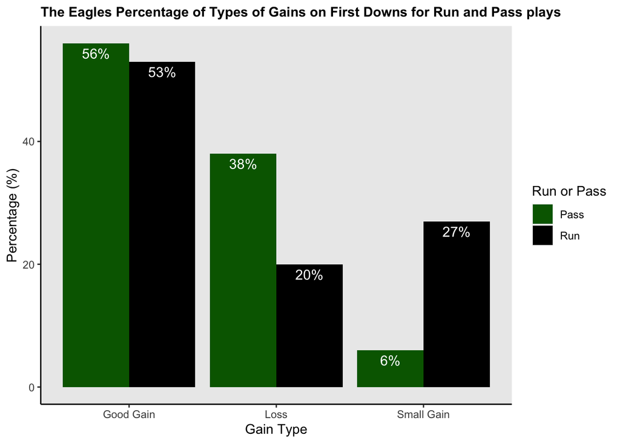

```r
#creating plot for eagles
ggplot(eagles_first, aes(x = gain_type, y = pct, fill = pff_RUNPASS)) + geom_bar(stat = "identity", position = "dodge") +
  ylab("Percentage (%)") + xlab("Gain Type") + ggtitle("The Eagles Percentage of Types of Gains on First Downs for Run and Pass plays ")+ guides(fill=guide_legend(title="Run or Pass"))+geom_text(aes(label=paste(round(pct),"%",sep ="")), vjust = 1.5,
             position = position_dodge(.9), size = 4, colour = "White") + theme(panel.border = element_blank(),
  panel.grid.major = element_blank(),
  panel.grid.minor = element_blank(),
  # Change axis line
  axis.line = element_line(colour = "black"),
  plot.title = element_text(face="bold", size=11)) + scale_fill_manual(values = c("Pass" = "Dark Green",
                                                                                  "Run" = "black"))
```

Looking at defensive formations on first downs for the cowboys

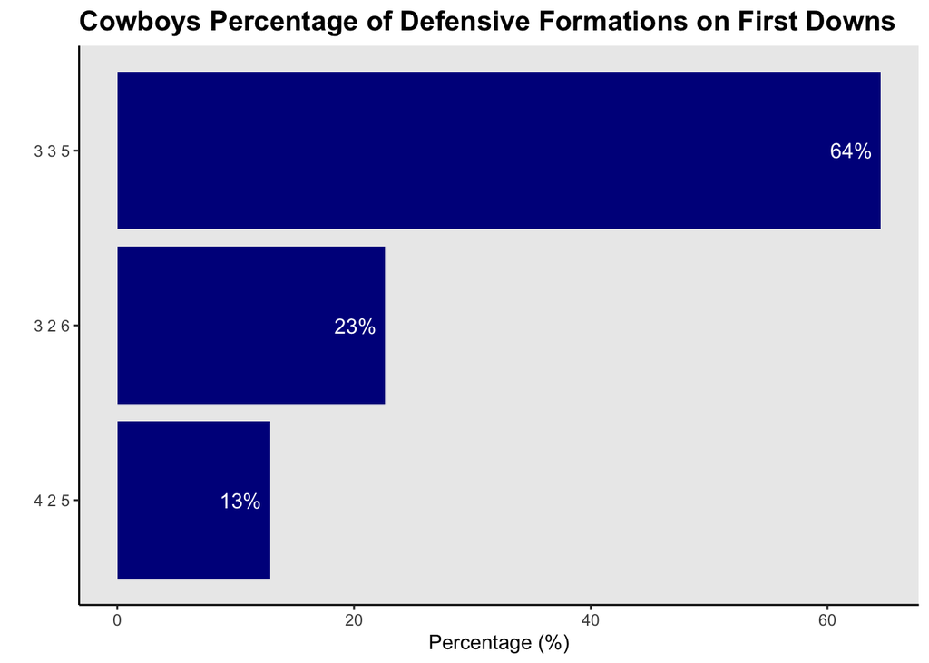

```r
dal_def_first <- first_downs %>% filter(pff_DEFTEAM == "DAL")
dal_def_first_count_df <- dal_def_first %>% group_by(DefPers) %>% summarise(count = n())
total <- sum(dal_def_first_count_df$count)
dal_def_first_count_df <- dal_def_first_count_df %>% mutate(total = total)
dal_def_first_count_df <- dal_def_first_count_df %>% mutate(pct = round(count/total,3)*100)
ggplot(dal_def_first_count_df, aes(x = reorder(DefPers,pct), y = pct)) + geom_bar(stat = "identity", fill = "dark blue") + coord_flip() + xlab("") + ylab("Percentage (%)") + ggtitle("Cowboys Percentage of Defensive Formations on First Downs") + geom_text(aes(label=paste(round(pct),"%",sep ="")), hjust = 1.2, size = 4, colour = "white") + theme(panel.border = element_blank(),
  panel.grid.major = element_blank(),
  panel.grid.minor = element_blank(),
  # Change axis line
  axis.line = element_line(colour = "black"),
  plot.title = element_text(face="bold", size=15))
```

```r
#As you can see, the Cowboys on first downs always ran with max only 6 players in the box. Also they only had 3 defensive linemen on 87% of all first downs, which leaves the run game very open. This confirms my assumptions from above.
```

getting micach parsons

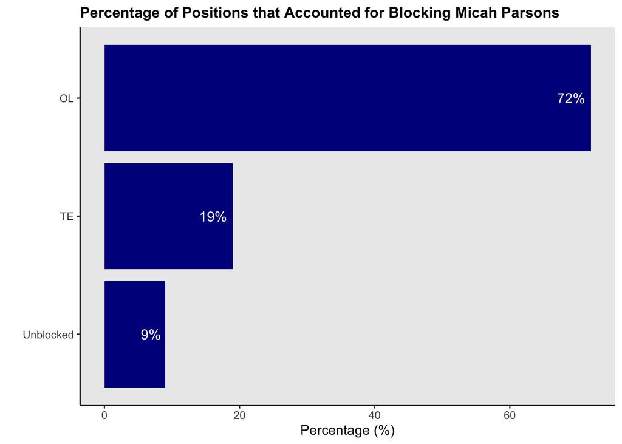

```r
micah_parsons <- defense %>% filter(PlayerID == 53441)
#getting offensive positions and id's
block_group <- offense %>% select(PlayerID, PosGroup) %>% distinct()
#joining data
micah_parsons <- micah_parsons %>% left_join(block_group, by=c('BlockID'='PlayerID'))
#seeing what position groups blocked Micah Parsons the Most
micah_parsons_sum <- micah_parsons %>% group_by(PosGroup) %>% summarise(total = n()) %>% mutate(PosGroup = ifelse(is.na(PosGroup) == TRUE,"Unblocked",PosGroup))
#getting snaps total
snaps <- sum(micah_parsons_sum$total)
#getting percentage
micah_parsons_sum %>% mutate(snaps = snaps, pct = round(total/snaps,2)*100) %>%
  ggplot(aes(x = reorder(PosGroup,pct), y = pct)) + geom_bar(stat = "identity", fill = "dark blue") + coord_flip() + xlab("") + ylab("Percentage (%)") + ggtitle("Percentage of Positions that Accounted for Blocking Micah Parsons") + geom_text(aes(label=paste(round(pct),"%",sep ="")), hjust = 1.2, size = 4, colour = "white") + theme(panel.border = element_blank(),
  panel.grid.major = element_blank(),
  panel.grid.minor = element_blank(),
  # Change axis line
  axis.line = element_line(colour = "black"),
  plot.title = element_text(face="bold", size=12))
```

```r
#in my opinion, only blocking Micah Parsons (one of the best defensive players in the league and best on the cowboys) with an offensive linemen 72% of his snaps is not ideal, and something that I think the Eagles could have improved upon. Especially in late game situations, making sure that he is accounted for by the best blockers on your team is essential. Otherwise in big situations, he will most likely make big plays. This can be seen late in the fourth quarter when he blew by Dallas Goedert (TE) and ultimately created a lane for his teammate to force a fumble, which pretty much sealed the game for the Cowboys.
```

3). What was the deciding factor in the game? In other words, what play(s) or other characteristic(s) of the game had the biggest impact on the outcome?